# (Ford GoBike System Data Exploration)

## by (Nourhan Farid)

## Preliminary Wrangling

> This analysis for data set includes information about individual rides made in a bike-sharing system covering the greater San Francisco Bay area. Each trip has it's own data like start and end time , start and end station with the station name , id and location, bike id and member gender

|  | duration_sec | start_time | end_time | start_station_id | start_station_name | start_station_latitude | start_station_longitude | end_station_id | end_station_name | end_station_latitude | end_station_longitude | bike_id | user_type | member_birth_year | member_gender | bike_share_for_all_trip |
| --- | --- | --- | --- | --- | --- | --- | --- | --- | --- | --- | --- | --- | --- | --- | --- | --- |
| 0 | 52185 | 2019-02-28 17:32:10.1450 | 2019-03-01 08:01:55.9750 | 21.0 | Montgomery St BART Station (Market St at 2nd St) | 37.789625 | -122.400811 | 13.0 | Commercial St at Montgomery St | 37.794231 | -122.402923 | 4902 | Customer | 1984.0 | Male | No |
| 1 | 42521 | 2019-02-28 18:53:21.7890 | 2019-03-01 06:42:03.0560 | 23.0 | The Embarcadero at Steuart St | 37.791464 | -122.391034 | 81.0 | Berry St at 4th St | 37.775880 | -122.393170 | 2535 | Customer | NaN | NaN | No |
| 2 | 61854 | 2019-02-28 12:13:13.2180 | 2019-03-01 05:24:08.1460 | 86.0 | Market St at Dolores St | 37.769305 | -122.426826 | 3.0 | Powell St BART Station (Market St at 4th St) | 37.786375 | -122.404904 | 5905 | Customer | 1972.0 | Male | No |
| 3 | 36490 | 2019-02-28 17:54:26.0100 | 2019-03-01 04:02:36.8420 | 375.0 | Grove St at Masonic Ave | 37.774836 | -122.446546 | 70.0 | Central Ave at Fell St | 37.773311 | -122.444293 | 6638 | Subscriber | 1989.0 | Other | No |
| 4 | 1585 | 2019-02-28 23:54:18.5490 | 2019-03-01 00:20:44.0740 | 7.0 | Frank H Ogawa Plaza | 37.804562 | -122.271738 | 222.0 | 10th Ave at E 15th St | 37.792714 | -122.248780 | 4898 | Subscriber | 1974.0 | Male | Yes |

### What is the structure of your dataset?

Data set has more than 174k bike sharing ride data covering the greater San Francisco Bay in 2019, Data set has lot of data like:

- Ride ID
- Start and End station
- Start and End time
- Member age and Gender

### Plus I added the following feautre :

- Member age
- Start and end day and hour

### What is/are the main feature(s) of interest in your dataset?

> I will investigate what the most visited station , peak days and hour .

### What features in the dataset do you think will help support your investigation into your feature(s) of interest?

> I think the following feature will help me:
> - trip duration
> - start and end day and hour
> - Member gender and age
> - User type

## Univariate Exploration

> In this section, investigate distributions of individual variables. If you see unusual points or outliers, take a deeper look to clean things up and prepare yourself to look at relationships between variables.

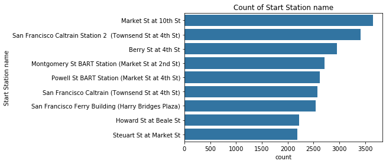

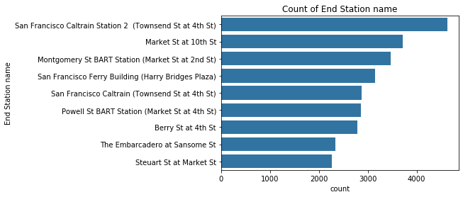

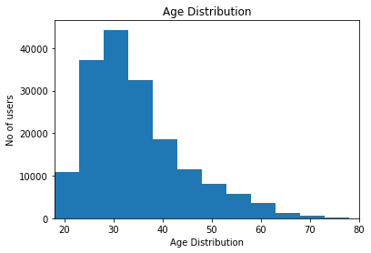

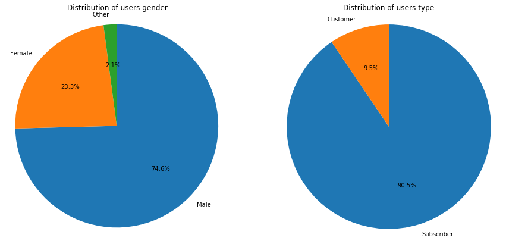

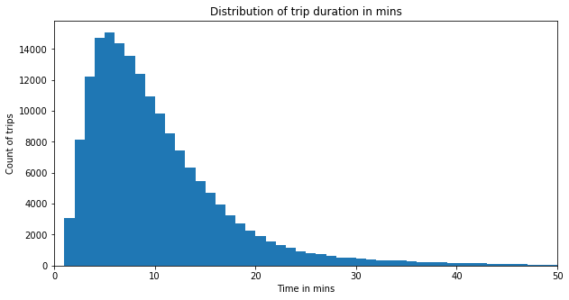

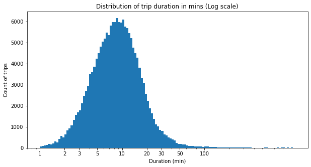

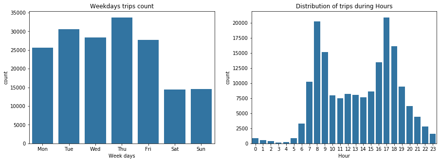

## Bivariate Exploration

> In this section, investigate relationships between pairs of variables in your data. Make sure the variables that you cover here have been introduced in some fashion in the previous section (univariate exploration).

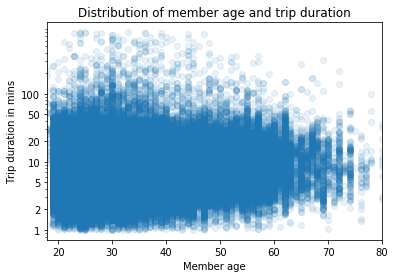

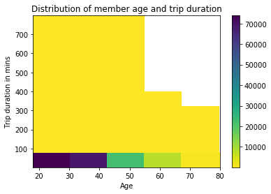

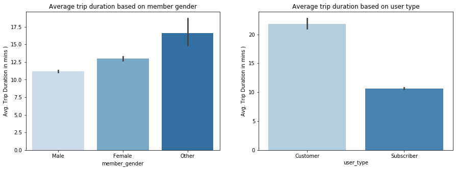

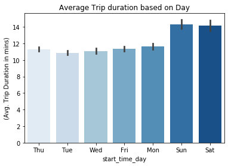

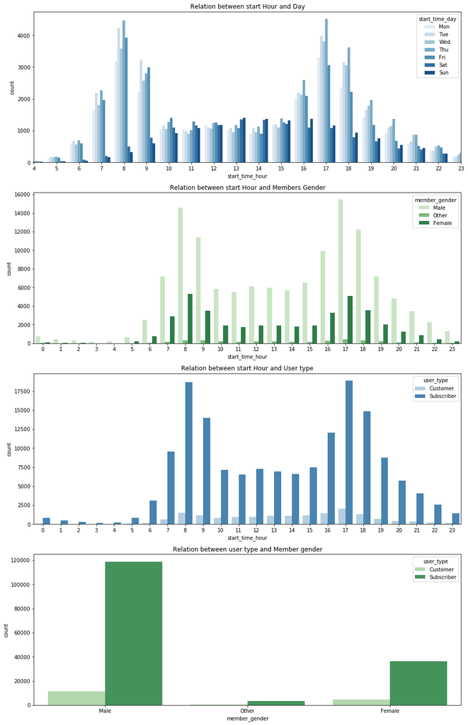

### Talk about some of the relationships you observed in this part of the investigation. How did the feature(s) of interest vary with other features in the dataset?

> By doing scatter plot and heatmap relation between the trip duration and member age I can notice that trip duration higher in age 20's and 30's

> Saturday and Sunday (weekend-days) are the highest day in the trip duration time

> Thursday and Tuesday have the most trip duration on 8am & 5 pm

> Male Peak hour is 5:00pm while female peak hour is 8 am

> Also subscriber peak hours are 8am and 5 pm but the customer peak hour is 5pm

> Male customers and subscribers are larger than female customers and subscribers

### Did you observe any interesting relationships between the other features (not the main feature(s) of interest)?

> Female average trip duration time is larger than males

> Customers average trip duration time is larger than subscriber

## Multivariate Exploration

> Create plots of three or more variables to investigate your data even further. Make sure that your investigations are justified, and follow from your work in the previous sections.

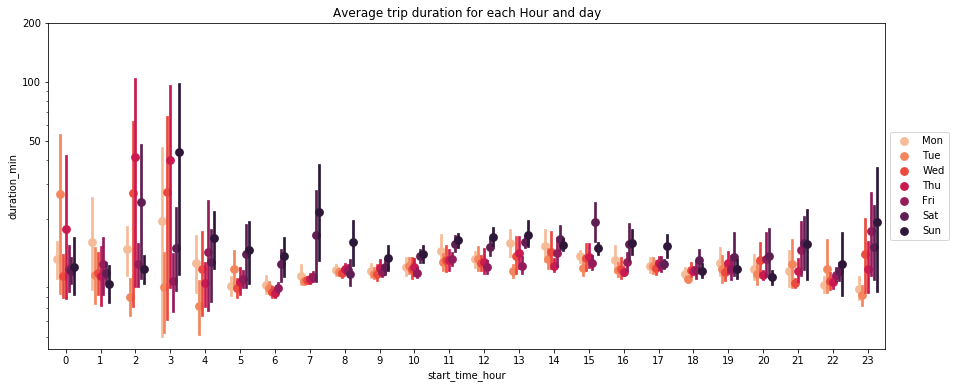

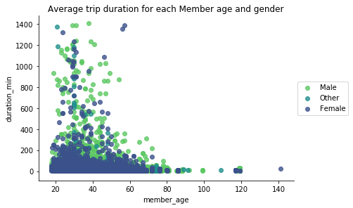

### Talk about some of the relationships you observed in this part of the investigation. Were there features that strengthened each other in terms of looking at your feature(s) of interest?

> I belive we almost have the same findings from the bivarial section

### Were there any interesting or surprising interactions between features?

> Yes , when I found that 3 am is the most trip duration on sunday

> Female bikers bike longer on average compared to male bikers.

> and when find the 'customer' user type has longer on average compared to 'Subscriber' bikers.